# Survival Analysis in Oncology Patients

2025-04-01

## 1. Introduction

Lung carcinoma is the leading cause of cancer-related mortality worldwide, with a 5-year survival rate of less than 20% in advanced stages [1]. This type of cancer is classified into two main subtypes: non-small cell lung cancer (NSCLC), which accounts for approximately 85% of cases, and small cell lung cancer (SCLC), a more aggressive form with a lower survival rate [2].

Despite advances in early detection and treatment, lung carcinoma remains a major global health challenge due to its late-stage diagnosis and high metastatic potential. Understanding the factors that influence survival is crucial for improving prognosis and developing more effective therapeutic strategies.

The objectives of survival analysis include the analysis of patterns of event times, the comparison of distributions of survival times in different groups of individuals and examining whether and by how much some factors affect the risk of an event of interest using survival curves, Cox regression models, and logistic regression [3]. The analysis identifies relevant clinical and demographic variables that may influence prognosis.

## 2. Material & Methods

### 2.1 Survival Analysis Design

1. *Observation Period*  
   The survival analysis was conducted using clinical data from oncology patients with a defined observation period ranging from the date of surgery (or diagnosis) up to the last known follow-up. The analysis includes follow-up times (Follow_up…290) measured in days, and the data were right-censored at the time of the last contact if no death was recorded. The data appears to have been recorded using structured clinical registries, likely derived from hospital records or follow-up systems
2. *Handling of Censored Data*  
   The event of interest was defined as *death* from any cause. Patients labeled as “Alive Free of Disease” or “Alive With Active Disease” in the Last_Known_Status column were coded as censored (Survival_Status = 0), whereas all forms of death (“Cancer-related Death” or “Other Causes Death”) were considered events (Survival_Status = 1).

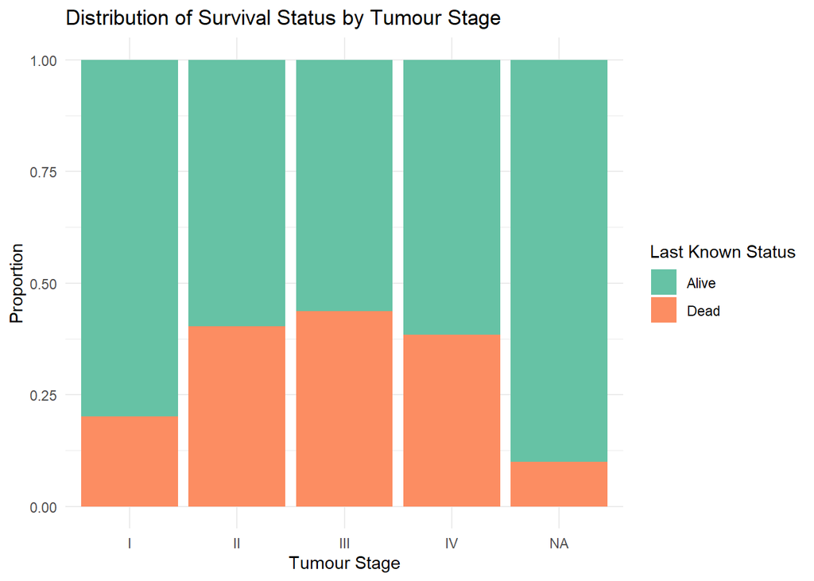

```r
# Bar plot: Distribution of survival status by TUMOUR STAGE
ggplot(data, aes(x = Pathologic_Tumour_Stage, fill = Survival_Status_texto)) +
  geom_bar(position = "fill") +
  scale_fill_brewer(palette = "Set2") +
  labs(
    title = "Distribution of Survival Status by Tumour Stage",
    x = "Tumour Stage",
    y = "Proportion",
    fill = "Last Known Status"
  ) +
  theme_minimal()
```

### 2.2 Data Curation

As previously mentioned, our objective is to study survival in cancer patients. To begin, we first verify that there are no missing values in the Survival_Status and Follow_up…290 columns. As we refine our selection of variables, we will remove any rows containing null values to ensure data consistency.

Our dataset includes 829 living patients and 258 deceased patients. While the data is somewhat imbalanced, both outcomes have a substantial number of cases, allowing for meaningful analysis

### 2.3 Preprocessing: Variable Transformation

In this section, the first thing we do is select continuous variables of interest, and then, convert them into discrete categories.

```r
# Confirm variable creation
summary(data[, c("Age_over_60", "BMI_category", "FVC_category", "Tumour_Size_cat")])
```

```
##  Age_over_60      BMI_category   FVC_category   Tumour_Size_cat
##  No :316     Underweight: 21   Very low:  3   Very small:150
##  Yes:741     Normal     :349   Low     : 68   Small     :420
##              Overweight :415   Moderate:127   Medium    :396
##              Obese      :272   Normal  :859   Large     : 91
```

Based on this summary, we decided:

- **For FVC_category**: group all but ‘Normal’ into ‘Altered’
- **For BMI_category**: group ‘Underweight’ + ‘Normal’ as ‘≤ Normal’, and the rest as ‘Overweight/Obese’

```r
# Confirm variable creation
summary(data[, c("Age_over_60", "BMI_category", "FVC_category", "Tumour_Size_cat")])
```

```
##  Age_over_60           BMI_category  FVC_category   Tumour_Size_cat
##  No :316     ≤ Normal        :370   Normal :859   Very small:150
##  Yes:741     Overweight/Obese:687   Altered:198   Small     :420
##                                                   Medium    :396
##                                                   Large     : 91
```

### 2.4 Variable Selection using Kaplan-Meier

To identify the most relevant variables for our analysis, we first review all available categorical variables and select those that, based on our criteria, are most closely related to cancer prognosis.

Once this initial selection is made, we generate Kaplan-Meier survival curves for each chosen variable, applying the log-rank test to compare survival distributions between groups. We examine these curves alongside their corresponding p-values to assess statistical significance. This process allows us to refine our selection, ensuring that only the most informative variables are included in subsequent analyses.

### 2.5 Logistic Regression

To further investigate the relationship between the selected variables and patient mortality, we performed multiple logistic regression to evaluate their joint effects on the likelihood of death. The model was constructed with the following steps:

- **Multiple Logistic Regression**: We included the variables identified through the Kaplan-Meier analysis in a multiple logistic regression model. The model was fit using a binomial logistic regression, where the dependent variable was Survival_Status (coded as 1 for deceased and 0 for alive). We used p-values (< 0.05) to assess the significance of each variable.
- **Simple Logistic Regressions**: To assess the independent contribution of each variable to mortality, we also performed simple logistic regressions by analyzing each variable separately with Survival_Status as the outcome.

The p-values from each regression were examined to confirm the variables that were statistically significant.

### 2.6 Cox Model

To evaluate the simultaneous effect of multiple clinical and demographic variables on patient survival, a multivariable Cox proportional hazards regression model was applied. The initial set of covariates included only those variables that showed significant association with survival in previous univariate analyses (Kaplan-Meier survival curves and log-rank tests). These included: Adenocarcinoma_Subtype, Smoking, Peripheral_Vascular_Disease, Cardiovascular_Morbidity, Pathologic_Tumour_Stage, Diabetes, High_Blood_Pressure, Ischemic_Heart_Disease, Dyspnea_Scale_mMRC, Tumour_Density, Age_over_60, and Tumour_Size_cat.

To avoid multicollinearity issues, we verified the independence of predictors using the Variance Inflation Factor (VIF), and removed any redundant variables.

Model performance was evaluated using the concordance index (C-index), which reflects the model’s ability to correctly rank survival times. The global significance of the model was assessed via the likelihood ratio test, Wald test, and score (log-rank) test.

### 2.7 Analysis of Variance

Beyond categorization (e.g., creating BMI groups), analyzing the variability of continuous variables provides important insights into their predictive potential. The rationale behind this approach is that variables with higher relative dispersion are more likely to have a significant impact on survival outcomes. Since raw variance can be influenced by differences in scale, we use the Coefficient of Variation (CV) as a standardized measure of dispersion. We calculate the CV for our four continuous variables (Age, BMI, FVC, and Tumor Size) and select only those with the highest CV values, ensuring that our features contribute meaningful variability to the analysis.

```r
print(cv_ordenado)
```

```
## Tumour_Size_mm            FVC            BMI            Age
##      0.4442076      0.2000199      0.1712193      0.1541693
```

The obtained variables were Tumour size and FVC.

## 3. Results

### 3.1 Kaplan-Meier curve with log-rank test

Using the log-rank test, we identified variables with p-values less than 0.05, indicating a significant association with survival. The following variables met this criterion:

- Histological_Subtype, Adenocarcinoma_Subtype, Smoking, Peripheral_Vascular_Disease, Cardiovascular_Morbidity, Pathologic_Tumour_Stage, Diabetes, High_Blood_Pressure, Ischemic_Heart_Disease, Dyspnea_Scale_mMRC, Tumour_Density, Peripheral_Vascular_Disease, Age_over_60, Tumour_Size_cat.

Here is the example of Smoking:

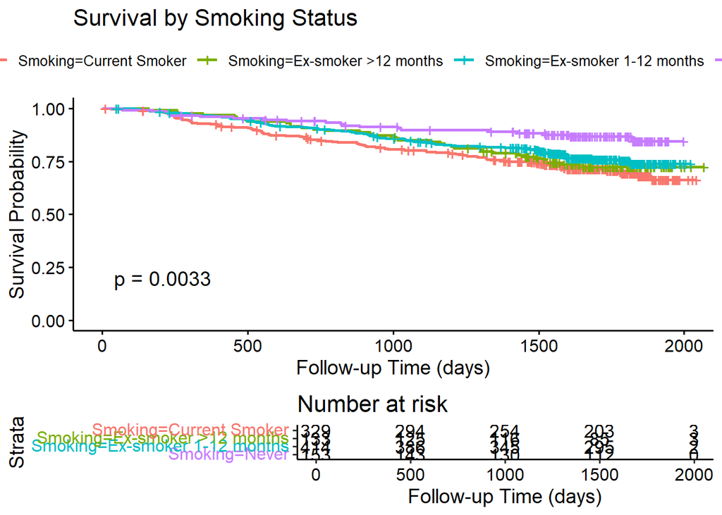

```r
# Kaplan-Meier curve

data <- data[data$Smoking != 'Unknown', ]

rrx <- which(is.na(data$Pathologic_Tumour_Stage))
if(length(rrx)>0){
  data <- data[-rrx,]
}

km_gender <- survfit(Surv(Follow_up...290, Survival_Status) ~ Smoking, data = data)
ggsurvplot(km_gender, data = data, risk.table = TRUE, pval = TRUE,
           title = "Survival by Smoking Status",
           xlab = "Follow-up Time (days)",
           ylab = "Survival Probability")
```

Here is an example of one of the variables we discarded, BMI:

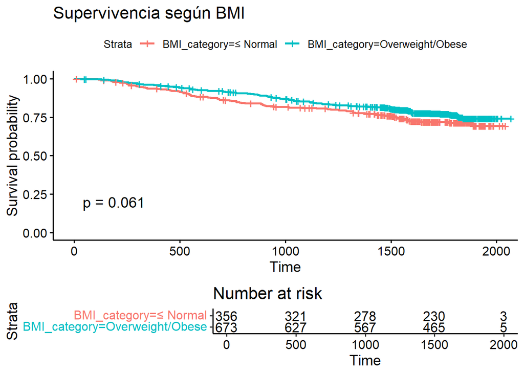

```r
# Aplicamos Kaplan-Meier de nuevo
modelo_bmi <- survfit(Surv(Follow_up...290, Survival_Status) ~ BMI_category, data = data)
ggsurvplot(modelo_bmi, data = data, risk.table = TRUE, pval = TRUE,
           title = "Supervivencia según BMI")
```

### 3.3 Logistic Regression

In our Logistic Regression analysis, we incorporated the variables identified in the previous section. The model results indicate that the variables Adenocarcinoma Subtype, Peripheral Vascular Disease, and Pathologic Tumor Stage are statistically significant (p-value < 0.05). A closer examination of the Estimates allows us to derive the following insights:

```r
print(significant_vars)
```

```
##                                                      Estimate     Pr(>|z|)
## (Intercept)                                        -1.8358966 2.434259e-05
## Adenocarcinoma_SubtypeInvasivo predominio lepídico -1.0947171 1.343323e-02
## Adenocarcinoma_SubtypeInvasivo predominio papilar  -1.1442620 1.792930e-02
## Peripheral_Vascular_DiseaseYes                      1.0215808 1.571695e-03
## Pathologic_Tumour_StageII                           0.8853062 5.651121e-03
## Pathologic_Tumour_StageIII                          1.1126592 3.022162e-03
```

In the following section, we present the p-values for one category of each variable to assess their statistical significance.

```r
print(resultados)
```

```
##                       Variable   p.value
## 1       Adenocarcinoma_Subtype 1.083e-03
## 2                      Smoking 6.247e-01
## 3  Peripheral_Vascular_Disease 3.770e-08
## 4     Cardiovascular_Morbidity 1.451e-02
## 5      Pathologic_Tumour_Stage 7.861e-06
## 6                     Diabetes 4.639e-03
## 7          High_Blood_Pressure 3.152e-03
## 8       Ischemic_Heart_Disease 7.798e-02
## 9           Dyspnea_Scale_mMRC 3.361e-03
## 10              Tumour_Density 2.869e-02
## 11                 Age_over_60 3.787e-03
## 12             Tumour_Size_cat 1.031e-02
```